# CIs Homework

Jerry Balloch

# Task 1.

Load the data again, clean_names(), and re-familiarise yourself with it

```r
# load in libraries and data
library(tidyverse)
library(janitor)
library(infer)

ames <- read_csv(here::here("data/ames.csv")) %>%
  clean_names()
```

# Task 2.

Investigate the distribution of lot_area. Is the distribution roughly normal? If not, what problems do you find?

**Answer:** The data is very compressed at the lower end of the scale. It is difficult to assertain the distribution as it only spans a few columns.

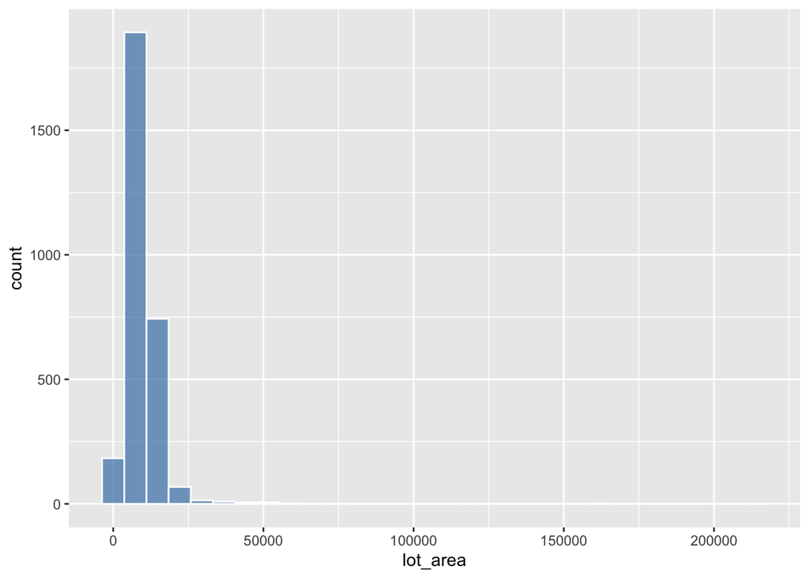

```r
ames %>%
  ggplot(aes(x = lot_area)) +
  geom_histogram(col = "white", fill = "steel blue", alpha = 0.7)
```

# Task 3.

Compute and visualise a bootstrap sampling distribution for the mean(lot_area) of the sold houses.

```r
# create a bootstrap with 5000 reps using `infer()`
infer_ames_resample <-  ames %>%
  # which variable we are interested in
  specify(response = lot_area) %>%
  # the replicates to resample
  generate(reps = 5000, type = "bootstrap") %>%
  # statistic we are interested in for each resample
  calculate(stat = "mean")

infer_ames_resample
```

| replicate | stat |
| --- | --- |
| 1 | 9997.278 |
| 2 | 10375.542 |
| 3 | 10192.925 |
| 4 | 9905.782 |
| 5 | 10146.686 |
| 6 | 10440.545 |
| 7 | 10408.000 |
| 8 | 10296.445 |
| 9 | 10303.158 |
| 10 | 10071.003 |

[output cut: 4990 more lines]

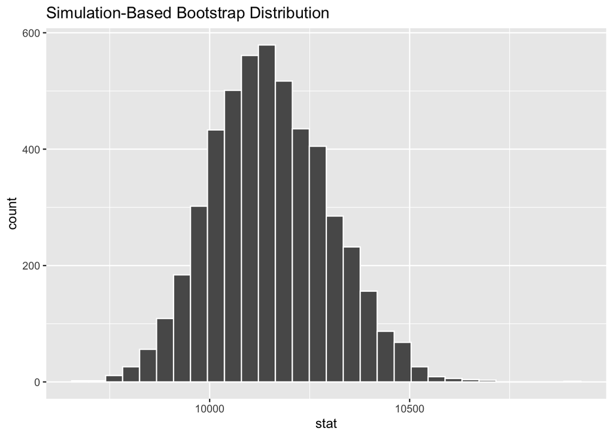

```r
# visualise the bootstrap
infer_ames_resample %>%
  visualise(bins = 30)
```

# Task 4.

Use your bootstrap distribution to calculate a 95% CI for mean(lot_area), and visualise it on the distribution

```r
# calculating a 95% confidence interval
infer_c_95 <- infer_ames_resample %>%
  get_confidence_interval(level = 0.95, type = "percentile")

infer_c_95
```

| lower_ci | upper_ci |
| --- | --- |
| 9880.027 | 10456.98 |

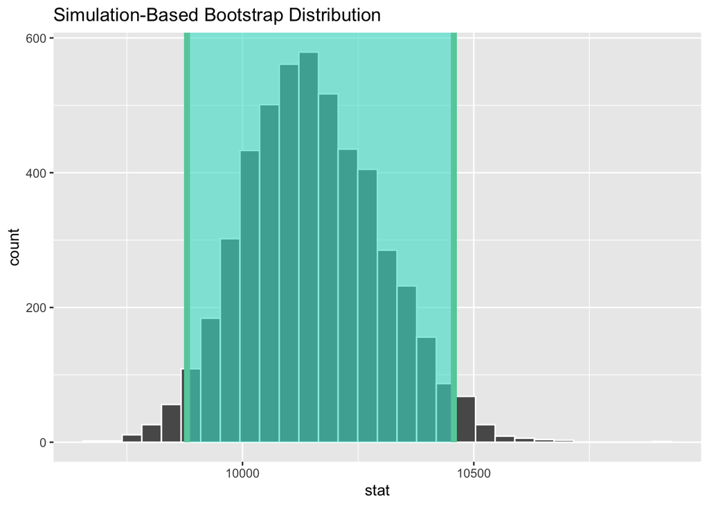

```r
# Visualisation of distribution and 95% CI
infer_ames_resample %>%
  visualise(bins = 30) +
  shade_confidence_interval(endpoints = infer_c_95)
```

# Task 5.

You would like to know the mean(lot_area) of the sold houses with higher confidence. Calculate the 99% CI for this variable (you can re-use your bootstrap distribution from above). Is it narrower or broader than the 95% CI? Does that make sense?

**Answer:** The 99% CI is a little broader than the 95% CI which is as I would expect.

```r
# calculating a 99% confidence interval
infer_c_99 <- infer_ames_resample %>%
  get_confidence_interval(level = 0.99, type = "percentile")

infer_c_99
```

| lower_ci | upper_ci |
| --- | --- |
| 9806.82 | 10542.17 |

```r
bind_rows(infer_c_95, infer_c_99)
```

| lower_ci | upper_ci |
| --- | --- |
| 9880.027 | 10456.98 |
| 9806.820 | 10542.17 |

# Task 6.

Calculate the point estimate of the mean(lot_area)

```r
# calculating the point estimate
mean_infer <- infer_ames_resample %>%
  summarise(mean = mean(stat))

mean_infer
```

| mean |
| --- |
| 10152.15 |

# 2 Extension

Task 1. Calculate a point estimate and 95% CI for the proportion of houses in the data built before 1920. Does the number of reps you use matter? [Investigate reps from 200 up to 50000, memory of your laptop permitting].

**Answer:** The number of houses built before 1920 is 176. Every time I calculate the CI with differing reps I get different results because of the random resampling going on. There seems to be no definable pattern to it. Is this because we are starting with more reps than there are original values ie. 200 reps from 176 values?

```r
# filter `year_built` to be less than 1920
pre_1920 <- ames %>%
  filter(year_built < "1920")

# create a bootstrap with 200 reps using `infer()`
pre_1920_resample_200 <-  pre_1920 %>%
  # which variable we are interested in
  specify(response = lot_area) %>%
  # the replicates to resample
  generate(reps = 200, type = "bootstrap") %>%
  # statistic we are interested in for each resample
  calculate(stat = "mean")

pre_1920_resample_200
```

| replicate | stat |
| --- | --- |
| 1 | 10443.034 |
| 2 | 9795.659 |
| 3 | 10070.761 |
| 4 | 9277.006 |
| 5 | 11068.369 |
| 6 | 10181.290 |
| 7 | 9421.932 |
| 8 | 9054.426 |
| 9 | 9698.415 |
| 10 | 10313.602 |

[output cut: 190 more lines]

```r
# calculating a 95% confidence interval
pre_1920_c_95_200 <- pre_1920_resample_200 %>%
  get_confidence_interval(level = 0.95, type = "percentile")

pre_1920_c_95_200
```

| lower_ci | upper_ci |
| --- | --- |
| 9007.271 | 10695.3 |

```r
# create a bootstrap with 10000 reps using `infer()`
pre_1920_resample_10000 <-  pre_1920 %>%
  # which variable we are interested in
  specify(response = lot_area) %>%
  # the replicates to resample
  generate(reps = 10000, type = "bootstrap") %>%
  # statistic we are interested in for each resample
  calculate(stat = "mean")

pre_1920_resample_10000
```

| replicate | stat |
| --- | --- |
| 1 | 10852.483 |
| 2 | 10133.858 |
| 3 | 9901.875 |
| 4 | 9155.295 |
| 5 | 9975.773 |
| 6 | 10869.824 |
| 7 | 10071.790 |
| 8 | 9680.710 |
| 9 | 10084.017 |
| 10 | 10012.119 |

[output cut: 9990 more lines]

```r
# calculating a 95% confidence interval
pre_1920_c_95_10000 <- pre_1920_resample_10000 %>%
  get_confidence_interval(level = 0.95, type = "percentile")

pre_1920_c_95_10000
```

| lower_ci | upper_ci |
| --- | --- |
| 9045.435 | 10806.91 |

```r
# create a bootstrap with 50000 reps using `infer()`
pre_1920_resample_50000 <-  pre_1920 %>%
  # which variable we are interested in
  specify(response = lot_area) %>%
  # the replicates to resample
  generate(reps = 50000, type = "bootstrap") %>%
  # statistic we are interested in for each resample
  calculate(stat = "mean")

pre_1920_resample_50000
```

| replicate | stat |
| --- | --- |
| 1 | 9550.057 |
| 2 | 9801.205 |
| 3 | 9673.392 |
| 4 | 10028.267 |
| 5 | 10775.727 |
| 6 | 9392.665 |
| 7 | 9584.193 |
| 8 | 9767.182 |
| 9 | 10398.449 |
| 10 | 9362.028 |

```r
# calculating a 95% confidence interval
pre_1920_c_95_50000 <- pre_1920_resample_50000 %>%
  get_confidence_interval(level = 0.95, type = "percentile")

pre_1920_c_95_50000
```

| lower_ci | upper_ci |
| --- | --- |
| 9052.75 | 10797.48 |

```r
bind_rows(pre_1920_c_95_200, pre_1920_c_95_10000, pre_1920_c_95_50000)
```

| lower_ci | upper_ci |
| --- | --- |
| 9007.271 | 10695.30 |
| 9045.435 | 10806.91 |
| 9052.750 | 10797.48 |